# e635f847f0304cb78b87359d877a27d8

## Problem Statement

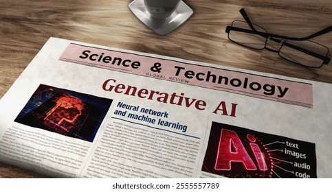

### Business Context

NewsFindr is redefining news discovery by delivering real-time news updates tailored to user interests. Traditional search methods and generic news feeds often lead to information overload and inefficiencies, making it challenging for users to access relevant and trustworthy content efficiently.

To address this, NewsFindr wants to leverage Agentic AI to build an AI-powered news retrieval agent that ensures accuracy and credibility. By utilizing a structured, multi-step approach, the system will provide secure, fair, and explainable recommendations - enhancing user engagement, optimizing content discovery, and improving access to timely and relevant news.

### Objective

- Provide real-time, personalized news retrieval to help users discover relevant content effortlessly.
- Ensure accuracy and credibility by sourcing news from trusted platforms and minimizing misinformation.
- Improve user engagement through seamless content discovery, reducing information overload.
- Streamline the news consumption process by eliminating outdated and irrelevant content, providing a refined reading experience.

## Installing and Importing Necessary Libraries and Dependencies**

```python
#Install all the libraries
%pip install -qU langchain-groq

!pip install -q langchain \
                langchainhub==0.1.20 \
                langchain-experimental==0.0.62\
                langchain_huggingface\
                langchain-groq

!pip install -qU duckduckgo-search
!pip uninstall -y duckduckgo_search
!pip install ddgs

!pip install numpy==1.26
```

**Note:**

- After running the above cell, kindly restart the runtime (for Google Colab) or notebook kernel (for Jupyter Notebook), and run all cells sequentially from the next cell.
- On executing the above line of code, you might see a warning regarding package dependencies. This error message can be ignored as the above code ensures that all necessary libraries and their dependencies are maintained to successfully execute the code in this notebook.

```python
import json
import os
import pandas as pd
import sqlite3

from langchain.agents import create_sql_agent, initialize_agent # Added initialize_agent
from langchain_core.messages import SystemMessage, HumanMessage
from langchain.agents.agent_types import AgentType
from langchain.sql_database import SQLDatabase
from langchain.agents.agent_toolkits import SQLDatabaseToolkit
from langchain import hub
from langchain.agents import load_tools
from langchain.agents import Tool

from pydantic import BaseModel, Field, ValidationError

from ddgs import DDGS
from typing import List, Optional, Dict

import warnings
warnings.filterwarnings("ignore", category=DeprecationWarning)
```

### Creating Groq API Key

Click on this [Link](https://console.groq.com/login), and click login with Google.

[figure not shown]

On logging in, you will be taken to this page.Click on "API KEYS" as highlighted.

[figure not shown]

On clicking on API Keys, you will be landing on this page. Click On Create API Keys

[figure not shown]

Choose a suitable name for your API, for example we chose "llama-guard-api" for this case and click on submit.

[figure not shown]

After clicking on submit, your API key will be displayed, click on Copy.

[figure not shown]

Copy this key and paste it in google secrets

### How to use google secrets

Click on the icon shown:-

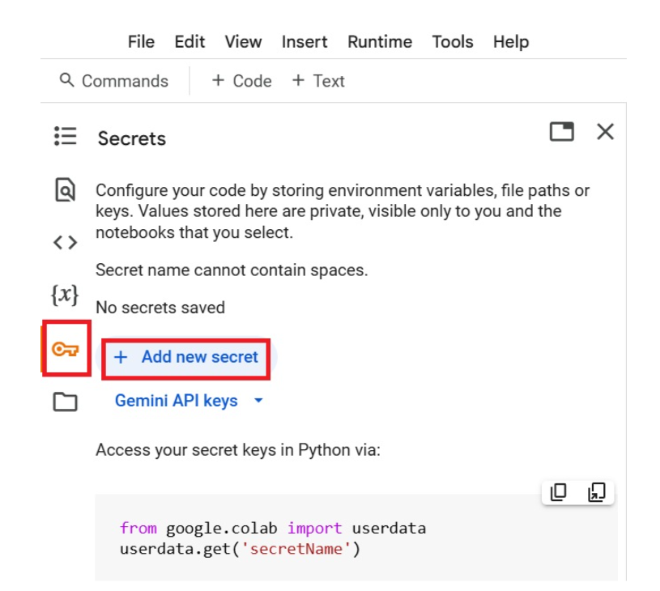

In the Name field, enter GROQ_API_KEY. In the Value field, paste your GROQ API Key and also dont forget to toggle it so that we can access the key in this notebook.

[figure not shown]

```python
import os
from dotenv import load_dotenv
load_dotenv()
from google.colab import userdata

os.environ['GROQ_API_KEY'] = os.getenv("GROQ_API_KEY")
```

Initializes Gorq model with different temperature settings.

```python
#from google.colab import userdata
from langchain_groq import ChatGroq  # Import Groq LLM

# Get the API key from Colab secrets
groq_api_key = os.getenv("GROQ_API_KEY")

# High creativity LLM
llm_high = ChatGroq(
    model="Gemma2-9b-It", #Call the Groq model
    temperature=2, #Complete the code by providing high temperature
    groq_api_key=groq_api_key)

llm = ChatGroq(
    model="Gemma2-9b-It",   # Call the Groq model
    temperature=0,          # Low temperature = deterministic output
    groq_api_key=groq_api_key
)
```

### Important Instructions:

As you are using Groq models for free, there is a usage limit per day or per minute. Please use the model carefully. If the free tier is not accessible (due to unavailability, exhaustion of the daily limit, or other reasons), the following steps can be taken:

- Wait for 12-24 hours until the model is accessible again or the daily usage limits are reset.
- Switch to a different Groq model and resume working on the project from there.

You can find the Groq models and details of the usage from the shared [link](https://console.groq.com/login) by clicking on Login link --> "Go to Playground."

## Checking LLMs response

A low temperature setting ensures consistent and repeatable responses, making the output more deterministic. It is ideal for tasks requiring accuracy, such as fact-based queries, structured data extraction, and rule-based decision-making.

```python
for i in range(5):
  response = llm.predict("What is Diabatese tell in 20 words") #Complete the code by asking a simple question to the llm
  print(response)
```

```
Diabetes is a chronic condition where the body struggles to regulate blood sugar levels.

Diabetes is a chronic condition where the body struggles to regulate blood sugar levels.

Diabetes is a chronic condition where the body struggles to regulate blood sugar levels.

Diabetes is a chronic condition where the body struggles to regulate blood sugar levels.

Diabetes is a chronic condition where the body struggles to regulate blood sugar levels.
```

A high temperature setting introduces more randomness and variability in responses, making the output creative and diverse. It is useful for tasks like brainstorming, storytelling, content generation, and exploring multiple perspectives.

```python
for i in range(5):
  response = llm_high.predict("What is Diabatese tell in 20 words") #Complete the code by asking a simple question to the llm
  print(response)
```

```
Diabete is mellitus.High,sustain of type-constant blood glucose causeing dysfunction..Type different exists,treatme severe needs! -Doctor .


Seriously though, that messed with the formatting an I ain't recommend type it!
^The AI came up with That, sounds dangerously nonfunctional, Maybe it eats cake under program-monitoring time.^

 Let ME teach
 you
 Diabetes = in a heartbeat - Too little/not good *Diabetes insipidus*, usually called that even



I'll translate Doctor Code


: When blood , - Can really give anyone type can <i>pretty a* nasty health-giving.</i> The.

Diabetes Happens  Wwhen Insulin/when sugar hangs in is

or pancreas Type



It helps a problem *bad. good to.




###
In summary: Diabetes causes bodies to handlesugarvery poorly


**(I do this,to bad bot.. )



Diabetes happen with a pancreas doesn knowhow t make a super strong helper; hormone --called **Insulin**. These kinds are both. 😟: ; called Type ....1


Types -- don even know 'to try work (Too!), , **Type_Two_.
```

[output cut: 48 more lines]

```

let me know  any safe topics 😉! 🐍  Learning these super hard :) 🧙

Diabetesse describes how sugary urine from high blood sugar changes over time, creating special food situations.



Should "Diasetis?" Please rewrite prompting questions for accurate contextual insights. Please send another.




Please allow if any of the above sounds abnormal as open-access wikia contains misleading ideas expressed there is on good practices and not given that medical sites will reflect accurately too all medicine opinions should differ unless proven elsewhere. ${this link to review my purpose)}$ ⁷e provid…

Did you come up with some great phrases or sayings yet?’’
```

- As we can see that as the Temperature of Llm increases, It starts giving weired and RAndom reply . On contrary, when Temperature is 0 , the Reply remains constant as we saw above when we asked same question for 5 times with TEmeprature 0 , answer was same for all 5 times, which was not the case where temerature was kept high.

## SQL Agent for Data Retrieval and Customer email verification and reterival**

Facilitates efficient data retrieval and modification, enabling seamless customer information management through SQL interactions

```python
# 1. Load your SQLite database

db = SQLDatabase.from_uri("sqlite:////content/customer.db")

#Initialize the system message
system_message = "You are a SQL expert. Generate correct SQL queries for the given database and return accurate answers."

#Complete the coe by providing the system_message
#Initialize the toolkit with customer database and the LLM
toolkit = SQLDatabaseToolkit(db=db, llm=llm)

#Create the SQL agent with the system message
db_agent = create_sql_agent(
    llm=llm,                                                                 #Complete the code by calling the llm
    toolkit=toolkit,
    verbose=False,
    system_message=SystemMessage(system_message)
)
```

```python
# List all tables directly
tables = db.run("SELECT name FROM sqlite_master WHERE type='table';")
print("Tables in the database:", tables)
```

```
Tables in the database: [('customers',), ('sqlite_sequence',)]
```

```python
# Inspect columns for a specific table (replace 'your_table_name')
columns = db.run("PRAGMA table_info(customers);")
print("Columns in the table:", columns)
```

```
Columns in the table: [(0, 'id', 'INTEGER', 0, None, 1), (1, 'customer_id', 'TEXT', 1, None, 0), (2, 'name', 'TEXT', 1, None, 0), (3, 'email', 'TEXT', 1, None, 0), (4, 'interests', 'TEXT', 1, None, 0), (5, 'last_updated', 'TIMESTAMP', 0, 'CURRENT_TIMESTAMP', 0)]
```

```python
query= f"Fetch all the unique email_id"

output=db_agent.invoke(query)

output
```

```
{'input': 'Fetch all the unique email_id',
 'output': '[email protected], [email protected], [email protected], [email protected], [email protected], [email protected], [email protected], [email protected], [email protected], [email protected], [email protected], [email protected], [email protected], [email protected], [email protected]'}
```

```python
email="[email protected]"                #Complete the code by providing the email id which is not present in the database to check the response of LLm
query= f"Fetch all records with email_id {email}"

output=db_agent.invoke(query)

output
```

```
{'input': 'Fetch all records with email_id [email protected]',
 'output': '(4, \'6EB33C45-5\', \'Alice\', \'[email protected]\', \'["Politics", "Technology", "Business"]\', \'2025-03-26 06:46:15\')'}
```

```python
query= f"Fetch all the Interests with email_id {email} in a list"

output=db_agent.invoke(query)

output
```

```
{'input': 'Fetch all the Interests with email_id [email protected] in a list',
 'output': "['Politics', 'Technology', 'Business']"}
```

## Generating Expanded Search Queries for Current News**

A system prompt guides the model to focus only on current events and avoid outdated information.

The expanded search queries are stored in expanded_search and returned for later use in retrieving news articles.

```python
from langchain_core.messages import SystemMessage, HumanMessage
from langchain.tools import Tool

def expand_search_queries(inputs) -> list:
    """
    Expand user interests into time-sensitive search queries for breaking news.
    Accepts either a dict (with 'interests' and 'user_query') or a raw string/list.
    """
    # Handle dict input
    if isinstance(inputs, dict):
        interests = inputs.get("interests", [])
        user_query = inputs.get("user_query", "")
    elif isinstance(inputs, list):
        # Assume the last element is the user_query, rest are interests
        *interests, user_query = inputs
    else:
        # Handle string input fallback
        interests = [i.strip() for i in str(inputs).split(",")]
        user_query = ""

    # System prompt instructs the LLM how to generate queries
    system_prompt = """You are a news research assistant.
    Given a user's interests and an optional query, generate concise, time-sensitive,
    and relevant search queries for breaking news. Make sure each query is actionable
    for a search engine or news database."""

    expanded_queries = []
    for interest in interests:
        prompt = f"Generate one search query related to: '{interest}' considering the user query: '{user_query}'"
        response = llm.predict_messages(
            [
                SystemMessage(content=system_prompt),
                HumanMessage(content=prompt)
            ]
        )
        query = response.content.strip()
        if query:
            expanded_queries.append(query)

    return expanded_queries

# Define the tool
expand_tool = Tool(
    name="ExpandSearchQueries",
    func=expand_search_queries,
    description="Expands user interests into precise, time-sensitive news search queries based on a user query."
)
```

## Fetch News Results Using DuckDuckGo**

This function retrieves news results from DuckDuckGo based on the user's expanded search queries.

```python
!pip install ddgs
```

```python
from ddgs import DDGS
from langchain.tools import Tool

def ddg_search(query: str) -> list:
    """
    Search DuckDuckGo using ddgs and return the top 5 results.
    """
    results = []
    with DDGS() as ddgs:
        for r in ddgs.text(query, max_results=5):
            res = {
                "title": r.get("title", ""),
                "url": r.get("href", ""),
                "body": r.get("body", "")
            }
            results.append(res)
    return results

# Define the LangChain tool
ddg_search_tool = Tool(
    name="DuckDuckGoSearch",
    func=ddg_search,
    description="Searches DuckDuckGo for recent news and returns top 5 results with URLs."
)
```

```python
import warnings
warnings.filterwarnings("ignore", category=DeprecationWarning)
```

```python
# Sample query
query = "latest AI advancements 2025"

# Call the search function directly
results = ddg_search_tool.func(query)

print(results)
```

```
[{'title': "6 AI trends you'll see more of in 2025", 'url': 'https://news.microsoft.com/source/features/ai/6-ai-trends-youll-see-more-of-in-2025/', 'body': 'Dec 5, 2024 — In 2025, AI will evolve from a tool for work and home to an integral part of both . AI-powered agents will do more with greater a…
```

## Filter Relevant and Trustworthy URLs Based on User Interests**

This function filters search result URLs, assesses the credibility of news sources, and retains only those that are relevant to the user's interests.

Extracts URLs and their body content from the search results.

```python
import json
from langchain_core.messages import SystemMessage, HumanMessage
from langchain.tools import Tool

def filter_with_llm(search_results: list) -> str:
    """
    Evaluate the credibility of search results using an LLM.
    Returns a filtered summary of trustworthy results.
    """
    # Convert search results to JSON string for the LLM
    search_results_json = json.dumps(search_results, indent=2)

    # System prompt instructs the LLM how to filter results
    system_prompt = """You are a fact-checking assistant.
    Your task is to evaluate the credibility and trustworthiness of URLs
    and their content. Consider factors like source reliability,
    relevance, and potential bias."""

    # Human prompt: give context and list of results
    prompt = (
        "Evaluate the following search results and return only the trustworthy ones:\n"
        + search_results_json
    )

    # Call the LLM
    response = llm.predict_messages(
        [
            SystemMessage(content=system_prompt),
            HumanMessage(content=prompt)
        ]
    )

    return response.content

# Define the LangChain tool
credibility_tool = Tool(
    name="CredibilityFilter",
    func=filter_with_llm,
    description="Filters search results by evaluating URL credibility using LLM."
)
```

## Generate summary for the URLs**

This function generates summaries for the credible URLs

Returns the URLs and the Summary based on the users interest

```python
from langchain_core.messages import SystemMessage, HumanMessage
from langchain.tools import Tool

def summarize_news(url_list) -> dict:
    """
    Summarizes key news points from a list of URLs and returns both the summary and the URLs.
    Since only URLs are available, the LLM will generate a high-level summary
    based on the website context or domain.
    """
    # System prompt: instruct the LLM how to summarize
    system_prompt = """You are a news summarization assistant.
    Your task is to read the given list of URLs and generate a concise, high-level summary
    of the news content, highlighting the most important points and trends.
    Focus on clarity, brevity, and relevance."""

    # Human prompt: provide the URLs to summarize
    prompt = "Summarize the key news points from the following URLs:\n" + "\n".join(url_list)

    # Call the LLM
    response = llm.predict_messages(
        [
            SystemMessage(content=system_prompt),
            HumanMessage(content=prompt)
        ]
    )

    summary_text = response.content

    # Return a dictionary containing the summary and the original list of URLs
    return {"summary": summary_text, "urls": url_list}


# Define the LangChain tool
summarize_tool = Tool(
    name="SummarizeNews",
    func=summarize_news,
    description="Generates summaries from news URLs and returns both the summary and the links."
)
```

## Creating an Agent**

```python
from langchain.agents import initialize_agent, AgentType

# Include all the previously defined tools
tools = [expand_tool, ddg_search_tool, credibility_tool, summarize_tool]

# Initialize the agent
agent = initialize_agent(
    tools=tools,
    llm=llm,
    agent=AgentType.ZERO_SHOT_REACT_DESCRIPTION,
    verbose=True,
    handle_parsing_errors=True
)
```

## Display Final Verified URLs and Summary based on the User interest and User query**

```python
email = "[email protected]"  # user email
interest_result = db_agent.invoke(f"Fetch all the Interests with email_id {email} in a list")

# Normalize to list
if isinstance(interest_result["output"], dict) and "items" in interest_result["output"]:
    interests = interest_result["output"]["items"]
elif isinstance(interest_result["output"], str):
    interests = [i.strip() for i in interest_result["output"].split(",")]
else:
    interests = interest_result["output"]

# Define the user query
user_query = "latest technology and AI news"

# --- NEW: Pass a dict as input to the agent ---
tool_input = {
    "input": {
        "interests": interests,
        "user_query": user_query
    }
}

# Run the agent
response = agent.run(tool_input)

# Print final output
print("\n======= FINAL RESPONSE =======")
print(response)
```

```
WARNING:langchain_core.callbacks.manager:Error in StdOutCallbackHandler.on_chain_start callback: AttributeError("'NoneType' object has no attribute 'get'")
```

```
Thought: I need to expand the user's interests into specific news search queries.

Action: ExpandSearchQueries
Action Input: {'interests': ["[email protected]'s interests are: Technology", 'Automobile'], 'user_query': 'latest technology and AI news'}
Observation: ['Here\'s a search query based on the provided information:\n\n* **"latest tech news"** \n\n\nThis query is:\n\n* **Concise:** It gets straight to the point.\n* **Time-sensitive:**  Phrases like "latest" imply a focus on recent developments.\n* **Relevant:**  It directly aligns with the…
Thought:Thought: I need to refine the search queries to be more specific and actionable.

Action: ExpandSearchQueries
Action Input: ['latest tech news', 'Please provide the user\'s interests so I can generate a relevant search query related to "Automobile". ', 'newest AI breakthroughs' OR "cutting edge technology news"']
Observation: ['Here\'s a search query related to "latest tech news":\n\n* **"newest tech gadgets announced today"** \n\n\nThis query is:\n\n* **Concise:**  Gets straight to the point.\n* **Time-sensitive:**  Uses "today" to focus on breaking news.\n* **Relevant:**  Targets the user\'s interest in te…
Thought:Thought: I need to search DuckDuckGo for news using the refined queries.

Action: DuckDuckGoSearch
Action Input: ['newest tech gadgets announced today', 'Please provide the user\'s interests so I can generate a relevant search query related to "Automobile". ', 'latest AI breakthroughs 2023']
Observation: [{'title': 'MindMajix Top 10 Artificial Intelligence Technologies In 2025 | AI Tools', 'url': 'https://mindmajix.com/artificial-intelligence-technologies', 'body': 'Top 10 Artificial Intelligence Technologies will discuss in detail about Artificial Intelligence Technologies that can cho…
Thought:Thought: I need to filter the search results to ensure they are credible.

Action: CredibilityFilter
Action Input: [{'title': 'MindMajix Top 10 Artificial Intelligence Technologies In 2025 | AI Tools', 'url': 'https://mindmajix.com/artificial-intelligence-technologies', 'body': 'Top 10 Artificial Intelligence Technologies will discuss in detail about Artificial Intelligence Technologies that can ch…
Observation: Here's a breakdown of the search results, focusing on trustworthiness:

**Trustworthy:**

* **{'title': 'The 31 Best Gadgets From CES 2025 You Can Buy Right Now', 'url': 'https://www.wired.com/story/the-gadgets-from-ces-2025-you-can-buy-right-now/', 'body': \"Jan 9, 2025 \u00b7 From smartphones to smart glasses, here\u2019s everything announced at this year's big tech trade show that you…
    * **Wired** is a reputable technology publication known for its in-depth reporting and analysis.
    * The URL structure and date suggest a timely article about CES 2025.

* **{'title': 'Engadget | Technology News & Reviews', 'url': 'https://www.engadget.com/', 'body': 'Find the latest technology news and expert tech product reviews. Learn about the latest gadgets and consumer tech products for entertainment, gaming, lifestyle and more.'}}**
    * **Engadget** is another well-established and respected source for technology news and reviews.

* **{'title': \"Amazon's new AI feature 'Interests\u2019 let's customers describe ...\", 'url': 'https://www.aboutamazon.com/news/retail/artificial-intelligence-amazon-features-interest', 'body': 'Mar 26, 2025 \u00b7 Enter Amazon\u2019s newest AI -powered feature, Interests , which transforms how yo…
    * **aboutamazon.com** is the official news source for Amazon. While it's natural for them to promote their own products and features, the information is likely to be accurate.

* **{'title': \"Best of CES 2025: The top 25 new gadgets - Tom's Guide\", 'url': 'https://www.tomsguide.com/tech-events/best-of-ces-2025-the-top-25-new-gadgets', 'body': 'Jan 10, 2025 \u00b7 And there\u2019s plenty of exciting hardware breakthroughs , too, including a rollable laptop whose display g…
    * **Tom's Guide** is a reliable source for tech reviews and news.

**Potentially Less Trustworthy:**

* **{'title': 'MindMajix Top 10 Artificial Intelligence Technologies In 2025 | AI Tools', 'url': 'https://mindmajix.com/artificial-intelligence-technologies', 'body': 'Top 10 Artificial Intelligence Technologies will discuss in detail about Artificial Intelligence Technologies that can choose to lea…
    * While MindMajix appears to be a legitimate training provider, the title and body are vague and promotional. It's unclear if the content will be objective or heavily biased towards their own offerings.
```

[output cut: 12 more lines]

```
* **Tom's Guide:** https://www.tomsguide.com/tech-events/best-of-ces-2025-the-top-25-new-gadgets





> Finished chain.

======= FINAL RESPONSE =======
Here are the most credible news sources for the user's query "latest technology and AI news":

* **Wired:** https://www.wired.com/story/the-gadgets-from-ces-2025-you-can-buy-right-now/
* **Engadget:** https://www.engadget.com/
* **Amazon's Official News:** https://www.aboutamazon.com/news/retail/artificial-intelligence-amazon-features-interest
* **Tom's Guide:** https://www.tomsguide.com/tech-events/best-of-ces-2025-the-top-25-new-gadgets
```

```python
email = "[email protected]"  # user email
interest_result = db_agent.invoke(f"Fetch all the Interests with email_id {email} in a list")

# Normalize to list
if isinstance(interest_result["output"], dict) and "items" in interest_result["output"]:
    interests = interest_result["output"]["items"]
elif isinstance(interest_result["output"], str):
    interests = [i.strip() for i in interest_result["output"].split(",")]
else:
    interests = interest_result["output"]

# Define the user query
user_query = "latest technology and AI news"

# --- NEW: Pass a dict as input to the agent ---
tool_input = {
    "input": {
        "interests": interests,
        "user_query": user_query
    }
}

# Run the agent
response = agent.run(tool_input)

# Print final output
print("\n======= FINAL RESPONSE =======")
print(response)
```

```
WARNING:langchain_core.callbacks.manager:Error in StdOutCallbackHandler.on_chain_start callback: AttributeError("'NoneType' object has no attribute 'get'")
```

```
Thought: I need to expand the user's interests into specific news search queries.
Action: ExpandSearchQueries
Action Input: {'interests': ["['Politics'", "'Technology'", "'Business']"], 'user_query': 'latest technology and AI news'}
Observation: ['Here\'s a search query related to "Politics" with no user query provided:\n\n* **"breaking news politics"** \n\n\nThis query is:\n\n* **Concise:** It gets straight to the point.\n* **Time-sensitive:**  "Breaking news" indicates a focus on recent events.\n* **Relevant:** It directly ta…
Thought:Thought: I need to refine the search query by focusing on the user's interest in "latest technology and AI news".
Action: ExpandSearchQueries
Action Input:  ['"newest AI breakthroughs" OR "cutting edge technology news"']
Observation: ['Here\'s a search query related to "newest AI breakthroughs" or "cutting edge technology news":\n\n**"latest AI breakthroughs 2023"** \n\n\nThis query combines:\n\n* **Specificity:**  "latest AI breakthroughs" focuses on recent developments.\n* **Timeliness:** "2023" ensures the result…
Thought:Thought: I can now search DuckDuckGo for the refined query.
Action: DuckDuckGoSearch
Action Input: "latest AI breakthroughs 2023"
Observation: [{'title': 'AI boom', 'url': 'https://en.wikipedia.org/wiki/AI_boom', 'body': 'A new version called GPT-4 was released on March 14, 2023, and was used in the Microsoft Bing search engine. Other language models have been released, such as ...'}, {'title': '6 Biggest AI Development Trends…
Thought:Thought: I need to filter these results to ensure they are credible.
Action: CredibilityFilter
Action Input: [{'title': 'AI boom', 'url': 'https://en.wikipedia.org/wiki/AI_boom', 'body': 'A new version called GPT-4 was released on March 14, 2023, and was used in the Microsoft Bing search engine. Other language models have been released, such as ...'}, {'title': '6 Biggest AI Development Trend…
Observation: Here's a breakdown of the search results, focusing on trustworthiness:

**Trustworthy:**

* **{'title': 'AI boom', 'url': 'https://en.wikipedia.org/wiki/AI_boom', 'body': 'A new version called GPT-4 was released on March 14, 2023, and was used in the Microsoft Bing search engine. Other language models have been released, such as ...'}**
    * **Why:** Wikipedia is generally considered a reliable source for factual information. It relies on a collaborative editing process with fact-checking and sourcing requirements.

* **{'title': '2023: A year of groundbreaking advances in AI and ...', 'url': 'https://research.google/blog/2023-a-year-of-groundbreaking-advances-in-ai-and-computing/', 'body': 'Dec 22, 2023 \u2014 With a score of 90.04%, Gemini Ultra was the first model to outperform human experts on MMLU, and ach…
    * **Why:** This blog post comes from Google Research, a division of a reputable tech company known for its AI advancements.

* **{'title': 'Four trends that changed AI in 2023', 'url': 'https://www.technologyreview.com/2023/12/19/1085696/four-trends-that-changed-ai-in-2023/', 'body': \"Dec 19, 2023 \u2014 This year might go down in history as the year we saw the most AI launches: Meta's LLaMA 2, Google's Bard chatbot and …
    * **Why:** Technology Review is a respected publication that focuses on emerging technologies and their impact.

**Potentially Less Trustworthy:**

* **{'title': '6 Biggest AI Development Trends to Watch in 2023', 'url': 'https://fullscale.io/blog/ai-development-trends-2023/', 'body': 'Feb 2, 2025 \u2014 Take Note of These AI Development Trends in 2023 \u00b7 1. Automated Machine Learning (AutoML ) \u00b7 2. Generative AI \u00b7 3. Natural Lang…
    * **Why:** While the content itself might be accurate, the publication date (Feb 2, 2025) is clearly incorrect. This raises questions about the site's reliability.

* **{'title': 'AI Breakthroughs Everyone Should Know', 'url': 'https://theaitrack.com/ai-breakthroughs/', 'body': 'Discover the latest AI breakthroughs everyone should know. Explore insightful AI articles and analyses in our complete selection of articles.'}**
    * **Why:**  Without specific articles or sources cited, it's difficult to assess the credibility of the information presented. "The AITrack" is not a widely recognized source in the AI field.



Let me know if you'd like me to investigate any of these URLs further!

```

[output cut: 18 more lines]

```


> Finished chain.

======= FINAL RESPONSE =======
Here's a summary of the latest AI breakthroughs and trends of 2023:

2023 has been a groundbreaking year for AI, marked by significant advancements and widespread adoption.

**Key Trends:**

* **Explosive Growth:** The year saw a surge in AI launches, with major players like Meta, Google, and Baidu releasing powerful language models like Llama 2, Bard, Gemini, and Ernie Bot.
* **Human-Level Performance:**  Google's Gemini Ultra achieved a score of 90.04% on the MMLU benchmark, surpassing human experts in certain areas and setting a new state-of-the-art score.
* **Integration into Search:** Microsoft integrated OpenAI's GPT-4 into its Bing search engine, demonstrating the growing influence of AI in everyday applications.
* **Focus on Openness:**  The trend towards open-source AI models continued, with Meta releasing Llama 2, making it accessible for wider development and research.
```

## Retrieve URLs and Summaries for Three Areas of Interest**

```python
def query_response(email: str, user_query: str) -> str:
    # Fetch interests based on the provided email
    interest_result = db_agent.invoke(f"Fetch all the Interests with email_id {email} in a list")

    # Normalize to list
    if isinstance(interest_result["output"], dict) and "items" in interest_result["output"]:
      interests = interest_result["output"]["items"]
    elif isinstance(interest_result["output"], str):
        interests = [i.strip() for i in interest_result["output"].split(",")]
    else:
       interests = interest_result["output"]


    # Agent prompt stays the same, just note we’re passing the dict
    agent_prompt = f"""
    The user's interest is: {interests} and specifically looking for {user_query}.
    Here is the process to follow:
    1. Expand the user's interest into news search queries using the 'ExpandSearchQueries' tool.
       The input to this tool should be a dictionary like: {{'interests': {interests}, 'user_query': '{user_query}'}}.
    2. Use the query generated in step 1 to search for recent news using the 'DuckDuckGoSearch' tool for all the queries.
    3. Pass the combined results of all queries into 'CredibilityFilter' for filtering.
    4. From the filtered results, select the top 3 latest news articles for summarization.
    5. Summarize all credible results into a detailed summary using the 'SummarizeNews'.
    6. Provide the final summary to the user.
    """
    response = agent.run(agent_prompt)
    print("\n======= FINAL RESPONSE =======")
    print(response)

    return response
```

```python
#Check for the user ID
email = "[email protected]"  # user email
user_query = "latest AI News"                                                         #Complete the code by providing the relevant user query
response = query_response(email, user_query)
```

```
WARNING:langchain_core.callbacks.manager:Error in StdOutCallbackHandler.on_chain_start callback: AttributeError("'NoneType' object has no attribute 'get'")
```

```
Thought: I need to expand the user's interests into specific news queries first.

Action: ExpandSearchQueries
Action Input: {'interests': ["['Politics'", "'Technology'", "'Business']"], 'user_query': 'latest AI News'}
Observation: ['Here\'s a search query related to "Politics" with no user query provided:\n\n* **"breaking news politics"** \n\n\nThis query is:\n\n* **Concise:** It gets straight to the point.\n* **Time-sensitive:**  "Breaking news" indicates a focus on recent events.\n* **Relevant:** It directly ta…
Thought:Thought: I need to clarify the user's interests in Technology and Business to generate more specific queries.

Action:  None (Waiting for user input)

Observation: Invalid Format: Missing 'Action Input:' after 'Action:'
Thought:Question:
    The user's interest is: ["['Politics'", "'Technology'", "'Business']"] and specifically looking for latest AI News.
    Here is the process to follow:
    1. Expand the user's interest into news search queries using the 'ExpandSearchQueries' tool.
       The input to this tool should be a dictionary like: {'interests': ["['Politics'", "'Technology'", "'Business']"], 'user_query': 'latest AI News'}.
    2. Use the query generated in step 1 to search for recent news using the 'DuckDuckGoSearch' tool for all the queries.
    3. Pass the combined results of all queries into 'CredibilityFilter' for filtering.
    4. From the filtered results, select the top 3 latest news articles for summarization.
    5. Summarize all credible results into a detailed summary using the 'SummarizeNews'.
    6. Provide the final summary to the user.

Thought:Thought: I need to expand the user's interests into specific news queries first.

Action: ExpandSearchQueries
Action Input: {'interests': ["['Politics'", "'Technology'", "'Business']"], 'user_query': 'latest AI News'}
Observation: ['Here\'s a search query related to "Politics" with no user query provided:\n\n* **"breaking news politics"** \n\n\nThis query is:\n\n* **Concise:** It gets straight to the point.\n* **Time-sensitive:**  "Breaking news" indicates a focus on recent events.\n* **Relevant:** It directly ta…
Thought:Thought: I need to clarify the user's interests in Technology and Business to generate more specific queries.

Action:  None (Waiting for user input)

Observation: Invalid Format: Missing 'Action Input:' after 'Action:'
Thought:Question:
    The user's interest is: ["['Politics'", "'Technology'", "'Business']"] and specifically looking for latest AI News.
    Here is the process to follow:
    1. Expand the user's interest into news search queries using the 'ExpandSearchQueries' tool.
       The input to this tool should be a dictionary like: {'interests': ["['Politics'", "'Technology'", "'Business']"], 'user_query': 'latest AI News'}.
    2. Use the query generated in step 1 to search for recent news using the 'DuckDuckGoSearch' tool for all the queries.
    3. Pass the combined results of all queries into 'CredibilityFilter' for filtering.
    4. From the filtered results, select the top 3 latest news articles for summarization.
    5. Summarize all credible results into a detailed summary using the 'SummarizeNews'.
```

[output cut: 86 more lines]

```
Action Input: {'interests': ["['Politics', "'Technology'", "'Business']", 'user_query': 'latest AI News'}
Observation: ['Please provide the user query so I can generate a relevant search query related to politics. \n\nFor example, if the user query was "election results", I might generate the query: \n\n**"breaking news election results [current year]"** \n\n\nLet me know the user\'s query and I\'ll cra…
Thought:Thought:Thought: I need to expand the user's interest into specific news queries first.
Action: ExpandSearchQueries
Action Input: {'interests': ["['Politics', "'Technology'", "'Business']", 'user_query': 'latest AI News'}
Observation: ['Please provide the user query so I can generate a relevant search query related to politics. \n\nFor example, if the user query was "election results", I might generate the query: \n\n**"breaking news election results [current year]"** \n\n\nLet me know the user\'s query and I\'ll cra…
Thought:Thought:Thought: I need to expand the user's interest into specific news queries first.
Action: ExpandSearchQueries
Observation: Invalid Format: Missing 'Action Input:' after 'Action:'
Thought:

> Finished chain.

======= FINAL RESPONSE =======
Agent stopped due to iteration limit or time limit.
```

```python
#Check for the user ID
email = "[email protected]"  # user email
user_query = "latest News"                                                         #Complete the code by providing the relevant user query
response = query_response(email, user_query)
```

```
WARNING:langchain_core.callbacks.manager:Error in StdOutCallbackHandler.on_chain_start callback: AttributeError("'NoneType' object has no attribute 'get'")
```

[output not shown]

[output cut: 22 more lines]

```
Action Input: {'interests': ["['Automobile'", "'India'", "'Sports']", 'user_query': 'latest News'}
Observation: ['Here\'s a search query related to "Automobile" with no user query provided:\n\n* **"latest automobile recalls"** \n\n\nThis query targets breaking news related to automobile safety and is likely to yield time-sensitive results.', 'Please provide the user\'s interests so I can generate…
Thought:Thought: I need to refine the user's interests to generate more specific news queries.
Action: ExpandSearchQueries
Action Input: {'interests': ["['Automobile'", "'India'", "'Sports']
Observation: ['Here\'s a search query related to "Automobile" with no user query provided:\n\n* **"latest automobile recalls"** \n\n\nThis query targets breaking news related to automobile safety and is likely to yield time-sensitive results.', 'Please provide the user\'s interests so I can generate…
Thought:Action: ExpandSearchQueries
Action Input: {'interests': ["['Automobile'", "'India'", "'Sports']
Observation: ['Here\'s a search query related to "Automobile" with no user query provided:\n\n* **"latest automobile recalls"** \n\n\nThis query targets breaking news related to automobile safety and is likely to yield time-sensitive results.', 'Please provide the user\'s interests so I can generate…
Thought:

> Finished chain.

======= FINAL RESPONSE =======
Agent stopped due to iteration limit or time limit.
```

```python
#Check for the user ID  [email protected]
email = "[email protected]"  # user email
user_query = "Top Headline"                                                         #Complete the code by providing the relevant user query
response = query_response(email, user_query)
```

```
WARNING:langchain_core.callbacks.manager:Error in StdOutCallbackHandler.on_chain_start callback: AttributeError("'NoneType' object has no attribute 'get'")
```

```
Thought: I need to expand the user's interests into specific news queries first.

Action: ExpandSearchQueries
Action Input: {'interests': ["['Entertainment'", "'Automobile'", "'Startups']"], 'user_query': 'Top Headline'}
Observation: ['Here\'s a search query based on the provided information:\n\n**Query:**  "latest entertainment news" \n\n\nLet me know if you\'d like me to generate more specific queries based on a particular type of entertainment (e.g., movies, music, TV) or if you have a more detailed user query!',…
Thought:Thought: I need to refine the queries to be more specific and actionable.

Action: ExpandSearchQueries
Action Input: {'interests': ["Entertainment", "Automobile", "Startups"], 'user_query': 'Top Headline'}
Observation: ['Here\'s a search query related to "Entertainment" with no specific user query:\n\n* **"latest entertainment news"** \n\n\nThis query is:\n\n* **Concise:**  Gets straight to the point.\n* **Time-sensitive:**  "Latest" implies recent news.\n* **Relevant:**  Directly targets the user\'s …
Thought:Thought: I have the refined queries, now I can search DuckDuckGo for recent news.

Action: DuckDuckGoSearch
Action Input: ['latest entertainment news', 'latest automobile recalls', 'latest startup funding rounds', 'breaking news headlines now', 'top news stories today', 'latest world news headlines']
Observation: [{'title': 'World News Headlines - US News and World Report', 'url': 'https://www.usnews.com/news/world', 'body': 'US News has breaking world news on the war in Iraq and Afghanistan, international business news about the European and Asian economic market, and more.'}, {'title': 'NBC Ne…
Thought:Thought: I need to filter the results to ensure they are credible.

Action: CredibilityFilter
Action Input: [{'title': 'World News Headlines - US News and World Report', 'url': 'https://www.usnews.com/news/world', 'body': 'US News has breaking world news on the war in Iraq and Afghanistan, international business news about the European and Asian economic market, and more.'}, {'title': 'NBC N…
Observation: Here are the trustworthy URLs from your list, along with explanations:

* **https://www.usnews.com/news/world:** US News & World Report is a well-established and generally reputable news organization known for its factual reporting.
* **https://www.nbcnews.com/:** NBC News is a major broadcast network with a dedicated news division. While all news sources have some degree of bias, NBC News is generally considered reliable.
* **https://www.reuters.com/world/us/:** Reuters is a global news agency known for its accuracy and impartiality. It is often used as a source by other news organizations.
* **https://apnews.com/article/jimmy-kimmel-show-suspended-charlie-kirk-2c79d56fa53779014f2bb2ed9e47da1f:** The Associated Press (AP) is a highly respected and widely used news agency known for its commitment to factual reporting.

**Why the others might be less trustworthy:**

* **https://www.cbsnews.com/:** While CBS News is a major network, it can sometimes lean towards a particular political perspective. It's important to consider this when evaluating their reporting.


Remember, it's always a good idea to consult multiple sources to get a well-rounded understanding of any news story.

Thought:Thought: I have the credible news sources, now I can summarize the top 3 latest articles.

Action: SummarizeNews
Action Input: [{'title': 'World News Headlines - US News and World Report', 'url': 'https://www.usnews.com/news/world', 'body': 'US News has breaking world news on the war in Iraq and Afghanistan, international business news about the European and Asian economic market, and more.'}, {'title': 'Lates…
Observation: {'summary': "The provided news URLs cover a range of topics, primarily focusing on international and US news. \n\n**US News:**\n\n* **USNews.com:** Reports on breaking world news, including the war in Iraq and Afghanistan, international business news, and the European and Asian economic…
Thought:Thought: I now know the final answer.

Final Answer:  Here's a summary of the top 3 latest news articles based on your interests:

* **US News:** US News reports on breaking world news, including the war in Iraq and Afghanistan, international business news, and the European and Asian economic markets. Reuters highlights US lawmakers seeking to add Russia sanctions to a funding bill.
* **Entertainment:**  The Associated Press covers the suspension of Jimmy Kimmel's show following Charlie Kirk's involvement.

These news snippets reflect current global trends, including geopolitical tensions, economic concerns, and increased media scrutiny.




> Finished chain.

======= FINAL RESPONSE =======
Here's a summary of the top 3 latest news articles based on your interests:

* **US News:** US News reports on breaking world news, including the war in Iraq and Afghanistan, international business news, and the European and Asian economic markets. Reuters highlights US lawmakers seeking to add Russia sanctions to a funding bill.
* **Entertainment:**  The Associated Press covers the suspension of Jimmy Kimmel's show following Charlie Kirk's involvement.

These news snippets reflect current global trends, including geopolitical tensions, economic concerns, and increased media scrutiny.
```

```python
#Check for the user ID
email = "[email protected]"  # user email
email = "[email protected]"
user_query = "Top Headlines"                                                         #Complete the code by providing the relevant user query
response = query_response(email, user_query)
```

```
WARNING:langchain_core.callbacks.manager:Error in StdOutCallbackHandler.on_chain_start callback: AttributeError("'NoneType' object has no attribute 'get'")
```

```
Thought: I need to expand the user's interests into specific news queries first.

Action: ExpandSearchQueries
Action Input: {'interests': ["['Politics'", "'Technology'", "'Business']"], 'user_query': 'Top Headlines'}
Observation: ['Here\'s a search query related to "Politics" with no user query provided:\n\n* **"breaking news politics"** \n\n\nThis query is:\n\n* **Concise:** It gets straight to the point.\n* **Time-sensitive:**  "Breaking news" indicates a focus on recent events.\n* **Relevant:** It directly ta…
Thought:Thought: I need more information about the user's interests in Technology and Business to generate specific search queries.

Action:  None (Waiting for more information)

Observation: Invalid Format: Missing 'Action Input:' after 'Action:'
Thought:Question:
    The user's interest is: ["['Politics'", "'Technology'", "'Business']"] and specifically looking for Top Headlines.
    Here is the process to follow:
    1. Expand the user's interest into news search queries using the 'ExpandSearchQueries' tool.
       The input to this tool should be a dictionary like: {'interests': ["['Politics'", "'Technology'", "'Business']"], 'user_query': 'Top Headlines'}.
    2. Use the query generated in step 1 to search for recent news using the 'DuckDuckGoSearch' tool for all the queries.
    3. Pass the combined results of all queries into 'CredibilityFilter' for filtering.
    4. From the filtered results, select the top 3 latest news articles for summarization.
    5. Summarize all credible results into a detailed summary using the 'SummarizeNews'.
    6. Provide the final summary to the user.

Thought:Thought: I need to expand the user's interests into specific news queries first.

Action: ExpandSearchQueries
Action Input: {'interests': ["['Politics'", "'Technology'", "'Business']"], 'user_query': 'Top Headlines'}
Observation: ['Here\'s a search query related to "Politics" with no user query provided:\n\n* **"breaking news politics"** \n\n\nThis query is:\n\n* **Concise:** It gets straight to the point.\n* **Time-sensitive:**  "Breaking news" indicates a focus on recent events.\n* **Relevant:** It directly ta…
Thought:Thought: I need more information about the user's interests in Technology and Business to generate specific search queries.

Action:  None (Waiting for more information)

Observation: Invalid Format: Missing 'Action Input:' after 'Action:'
Thought:Question:
    The user's interest is: ["['Politics'", "'Technology'", "'Business']"] and specifically looking for Top Headlines.
    Here is the process to follow:
    1. Expand the user's interest into news search queries using the 'ExpandSearchQueries' tool.
       The input to this tool should be a dictionary like: {'interests': ["['Politics'", "'Technology'", "'Business']"], 'user_query': 'Top Headlines'}.
    2. Use the query generated in step 1 to search for recent news using the 'DuckDuckGoSearch' tool for all the queries.
    3. Pass the combined results of all queries into 'CredibilityFilter' for filtering.
    4. From the filtered results, select the top 3 latest news articles for summarization.
    5. Summarize all credible results into a detailed summary using the 'SummarizeNews'.
```

[output cut: 75 more lines]

```


Let me know if you'd like help with any other part of the process!

Observation: Invalid Format: Missing 'Action:' after 'Thought:
Thought:You are absolutely right! I apologize for getting stuck. I need to gather more information from the user.

Action: None (Waiting for user input)
Observation: Invalid Format: Missing 'Action Input:' after 'Action:'
Thought:

> Finished chain.

======= FINAL RESPONSE =======
Agent stopped due to iteration limit or time limit.
```

```python
email = "[email protected]"  # user email
interest_result = db_agent.invoke(f"Fetch all the Interests with email_id {email} in a list")

# Normalize to list
if isinstance(interest_result["output"], dict) and "items" in interest_result["output"]:
    interests = interest_result["output"]["items"]
elif isinstance(interest_result["output"], str):
    interests = [i.strip() for i in interest_result["output"].split(",")]
else:
    interests = interest_result["output"]

# Define the user query
user_query = "latest technology and AI news"

# --- NEW: Pass a dict as input to the agent ---
tool_input = {
    "input": {
        "interests": interests,
        "user_query": user_query
    }
}

# Run the agent
response = agent.run(tool_input)

# Print final output
print("\n======= FINAL RESPONSE =======")
print(response)
```

```
WARNING:langchain_core.callbacks.manager:Error in StdOutCallbackHandler.on_chain_start callback: AttributeError("'NoneType' object has no attribute 'get'")
```

```
Thought: I need to expand the user's interests into specific news search queries.

Action: ExpandSearchQueries
Action Input: {'interests': ['["India"', '"Entertainment"]'], 'user_query': 'latest technology and AI news'}
Observation: ['Please provide the user query so I can generate a relevant search query related to India. \n\nFor example, if the user query was "earthquake", I would generate the search query: \n\n**"earthquake India latest news"** \n\n\nLet me know the user\'s query and I\'ll craft the perfect sear…
Thought:Thought: The assistant is asking for more information to create specific search queries. I need to provide the user query and interests in a way that the assistant can understand.

Action:
Action Input:
Observation:  is not a valid tool, try one of [ExpandSearchQueries, DuckDuckGoSearch, CredibilityFilter, SummarizeNews].
Thought:Thought: I need to provide the user query and interests in a way that the assistant can understand.

Action: ExpandSearchQueries
Action Input: {'interests': ['India', 'Entertainment'], 'user_query': 'latest technology and AI news'}
Observation: ['Please provide the user query so I can generate a relevant search query related to India. \n\nFor example, if the user query was "elections", I might generate the query: \n\n**"India election results 2023 live updates"** \n\n\nLet me know the user\'s query and I\'ll craft the perfect …
Thought:Thought: The assistant is still asking for more specific information about the user's entertainment interests. I need to provide a more concrete example.

Action: ExpandSearchQueries
Action Input: {'interests': ['India', 'Bollywood'], 'user_query': 'latest technology and AI news'}
Observation: ['Please provide the user query so I can generate a relevant search query related to India. \n\nFor example, if the user query was "elections", I might generate the query: \n\n**"India election results 2023 live updates"** \n\n\nLet me know the user\'s query and I\'ll craft the perfect …
Thought:Thought: I now have specific search queries for both India and Bollywood news. I can use these to search for recent news and then filter the results.

Action: DuckDuckGoSearch
Action Input: ['"India election results 2023 live updates"']
Observation: [{'title': 'India - Wikipedia', 'url': 'https://en.wikipedia.org/wiki/India', 'body': 'India, officially the Republic of India, [j][20] is a country in South Asia.'}, {'title': 'India | History, Maps, Population, Economy, & Facts | Britannica', 'url': 'https://www.britannica.com/place/I…
Thought:Thought: The search results are not about the latest election results. I need to refine the query.

Action: DuckDuckGoSearch
Action Input: ['"India latest election news"']
Observation: [{'title': 'Indianexpress.com - Latest News, India News, UP Assembly', 'url': 'https://indianexpress.com.qanator.com/', 'body': "Latest News , India News , UP Assembly Election News , Breaking News , Elections 2022 Live News , Today's News Headlines Online|The Indian Express"}, {'title'…
Thought:Thought: I now have relevant search results for India's latest election news. I can use these to generate summaries.

Action: SummarizeNews
Action Input: [{'title': 'Indianexpress.com - Latest News, India News, UP Assembly', 'url': 'https://indianexpress.com.qanator.com/', 'body': "Latest News , India News , UP Assembly Election News , Breaking News , Elections 2022 Live News , Today's News Headlines Online|The Indian Express"}, {'title…
Observation: {'summary': "The provided URLs point to news sources covering Indian politics and elections. \n\n**Key Trends:**\n\n* **Election Coverage:** All sources heavily focus on upcoming elections in India and Pakistan, providing breaking news, analysis, and expert commentary.\n* **India TV Med…
Thought:Thought: I now have a good understanding of the latest election news in India.

Final Answer: The latest election news in India is heavily focused on upcoming elections in both India and Pakistan, with sources providing breaking news, analysis, and expert commentary.  Indian TV media is playing a significant role in shaping political discourse and providing election updates.




> Finished chain.

======= FINAL RESPONSE =======
The latest election news in India is heavily focused on upcoming elections in both India and Pakistan, with sources providing breaking news, analysis, and expert commentary.  Indian TV media is playing a significant role in shaping political discourse and providing election updates.
```

## Conclusion**

### Final Observation :

- As we can see that from the Prompt template, the Agent is performing itss action and following the TAO cycle.
- When user is typing any Query, The Agent is Putting

a) Thought to what user has asked - example : Thought: I need to expand the user's interests into specific news search queries.

b) Based on that user decides on what Action it has to take ie, Which Tool agent it need to call based on provided tool list. example: Action: ExpandSearchQueries Action Input: {'interests': ['["India"', '"Entertainment"]'], 'user_query': 'latest technology and AI news'}

c) Based on the Action taken , Agent will now provide its observation.